# Hard Work Chapter 3

Brother Saunders

Selected solutions to go along with the Student Solution Manual.

## Problem 3.3 Solutions

```r
# Load the Data:
p1.19 <- read.table("http://www.stat.ufl.edu/~rrandles/sta4210/Rclassnotes/data/textdatasets/KutnerData/Chapter%20%201%20Data%20Sets/CH01PR19.txt")

# Rewrite the column names to be "Y" and "X" to match the textbook:
colnames(p1.19) <- c("Y","X")
```

### Part A

> Prepare a box plot for the ACT scores $X_i$. Are there any noteworthy features in this plot?

You could notice things that I miss here, but the only noteworthy thing that I see in this boxplot is that the ACT scores $X_i$ appear to be normally distributed.

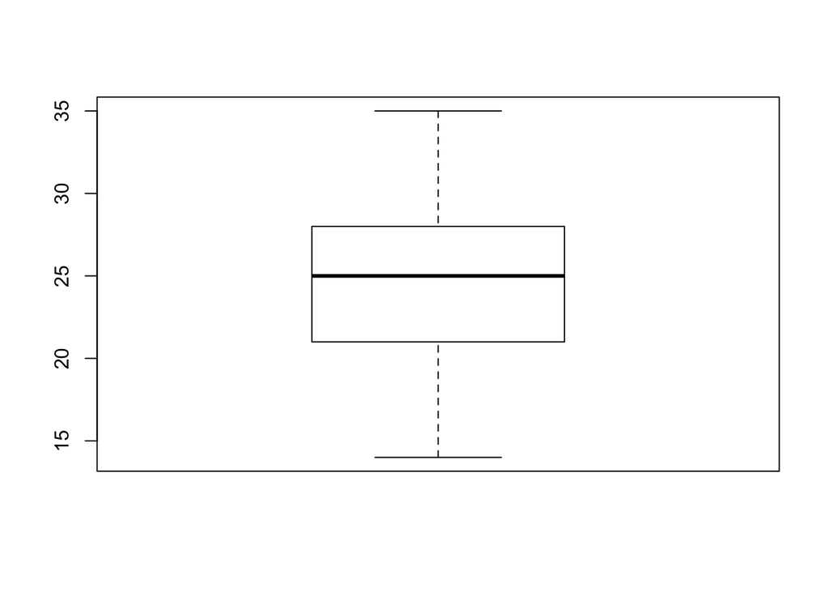

```r
boxplot(p1.19$X)
```

### Part B

> Prepare a dot plot of the residuals. What information does this plot provide?

```r
p1.19.lm <- lm(Y ~ X, data=p1.19)
names(p1.19.lm)
```

```
##  [1] "coefficients"  "residuals"     "effects"       "rank"
##  [5] "fitted.values" "assign"        "qr"            "df.residual"
##  [9] "xlevels"       "call"          "terms"         "model"
```

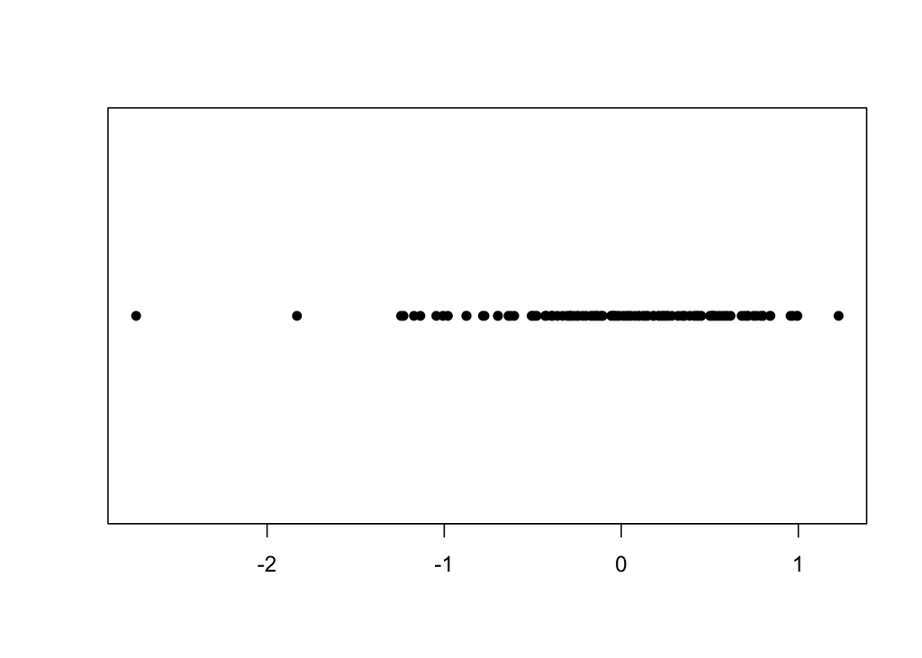

```r
stripchart(p1.19.lm$residuals, method="stack", pch=16)
```

```r
    # note: the option method="stack" stacks repeated values
    # the option pch=16 controls the plotting characters to be small filled cirlces.
```

To be honest, I think they meant to ask for a dot plot of the $X_i$ (Part a) and a boxplot of the residuals (Part b). However, as requested, the dot plot of the residuals is produced above, and is totally worthless. Just for fun, notice what the dot plot of the $X_i$ looks like:

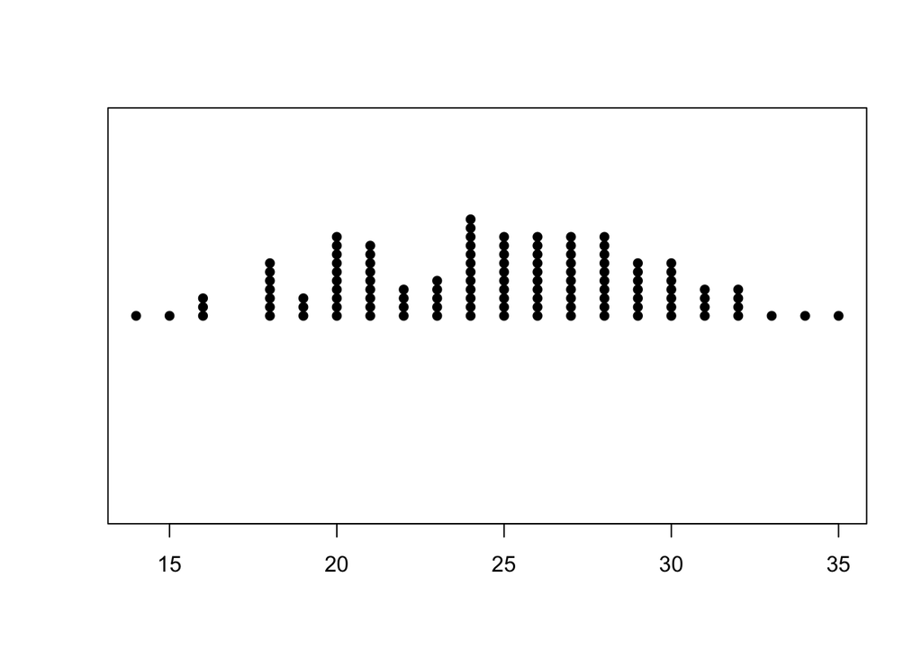

```r
stripchart(p1.19$X, method="stack", pch=16)
```

and what the boxplot of the residuals looks like:

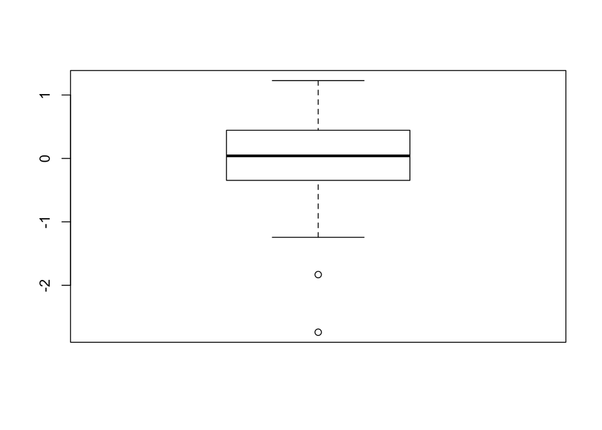

```r
boxplot(p1.19.lm$residuals)
```

### Part C

> Plot the residuals $\epsilon_i$ against the fitted values $\hat{Y_i}$. What departures from regression model (2.1) can be studied from this plot? What are your findings?

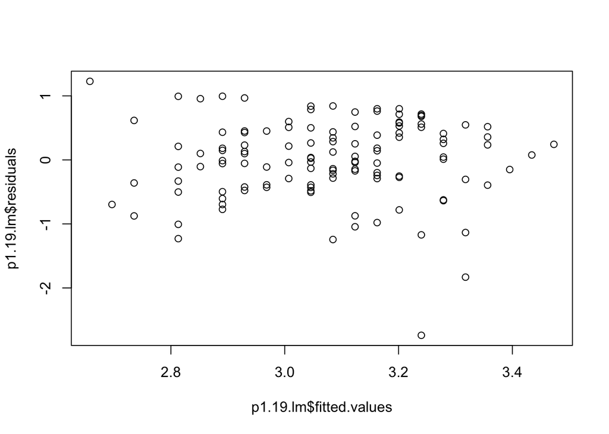

```r
plot(p1.19.lm$residuals ~ p1.19.lm$fitted.values)
```

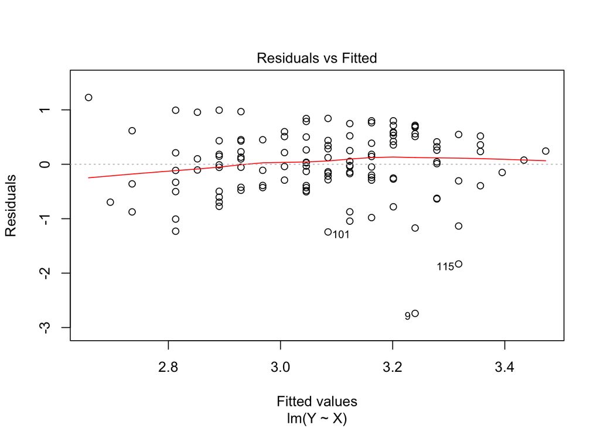

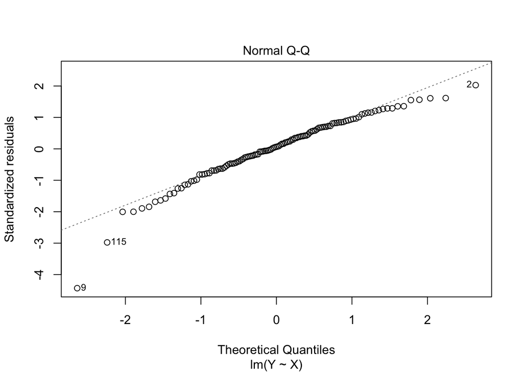

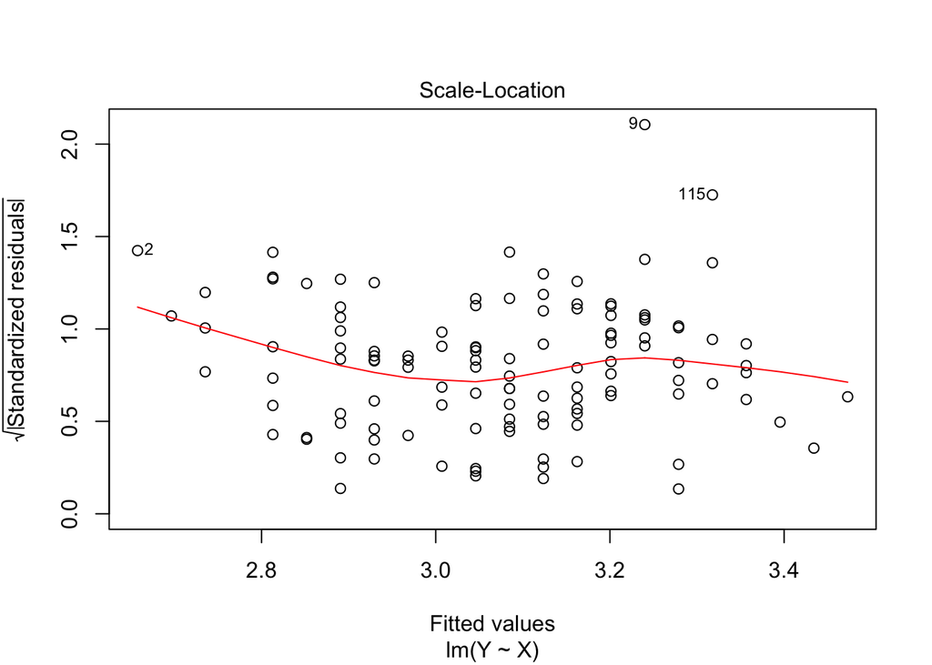

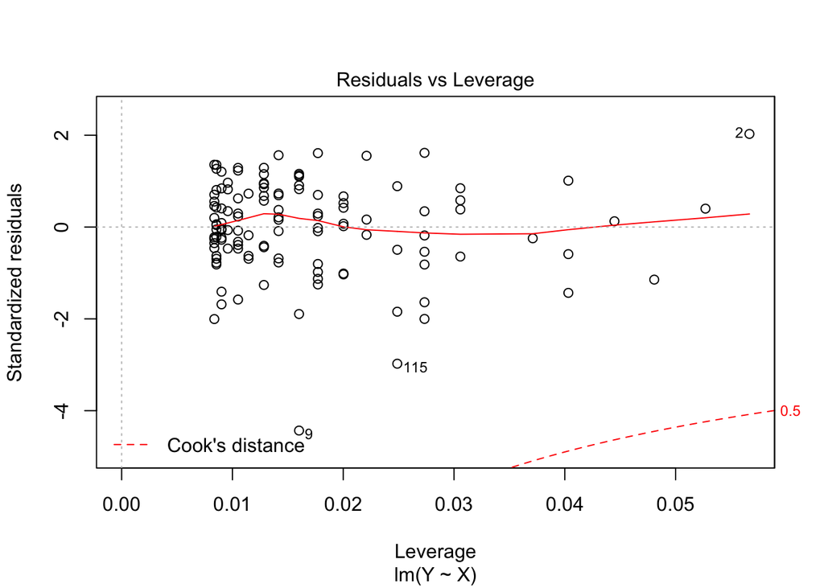

```r
# Or, alternatively you get several diagnostic plots when you simply run:
plot(p1.19.lm)
```

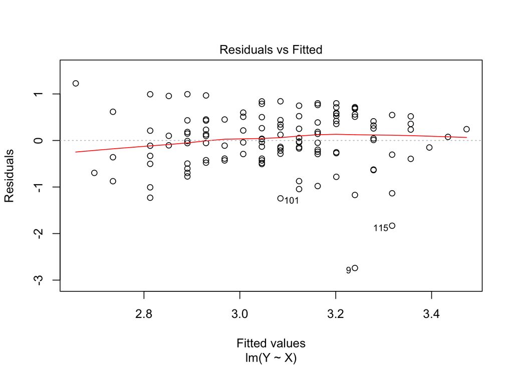

```r
# The only ones we are interested in for the current problem is the first one:
plot(p1.19.lm, which=c(1))
```

As stated at the bottom of page 104 of the textbook, “Whether a linear regression function is appropriate for the data being analyzed can be studied from a residual plot against the predictor variable, or, equivalently, from a residual plot against the fitted values.” Further, as stated on the top of page 107 of the textbook, “Plots of the residuals against the predictor variable or fitted values are not only helpful to study whether a linear regression function is appropriate but also examine whether the variance of the error terms is constant.” Also, the top part of page 108 states, “outliers can be identified from residual plots against $X$ [the predictor variable] or $\hat{Y}$ [the fitted values]…”

In conclusion, the residual vs. fitted values plot can be used to decide if

- the linear model is appropriate for the data,
- the variance is constant,
- there are any residuals that could potentially be outliers.

That covers 3 of the 6 possible departures from the simple linear regression model (2.1) that are listed on page 103 of the textbook with looking at just one plot!

This particular residual vs. fitted plot suggests that the linearity of the model could be called into question given the slight curving trend of the data shown by the red “lowess” line (see pages 138 and 139 of your textbook for what a lowess curve is). Also, there is likely an outlier (labeled g with an fitted value of just over 3.2). Finally, it is difficult to tell if the constant variance is satisfied or not because of the slight non-linear nature of the data. The constant variance is certainly questionable, but there is perhaps not enough evidence to conclude that the variance is not constant.

### Part D

> Prepare a normal probability plot of the residuals. Also obtain the coefficient of correlation between the ordered residuals and their expected values under normality. Test the resonableness of the normality assumption here using Table B.6 and $\alpha=0.05$. What do you conclude?

To answer this question, you will need to study Section 3.5 (one paragraph) and pages 110 and 111, the portion titled “Normal Probability Plot.” The following R commands may be useful to you in doing this.

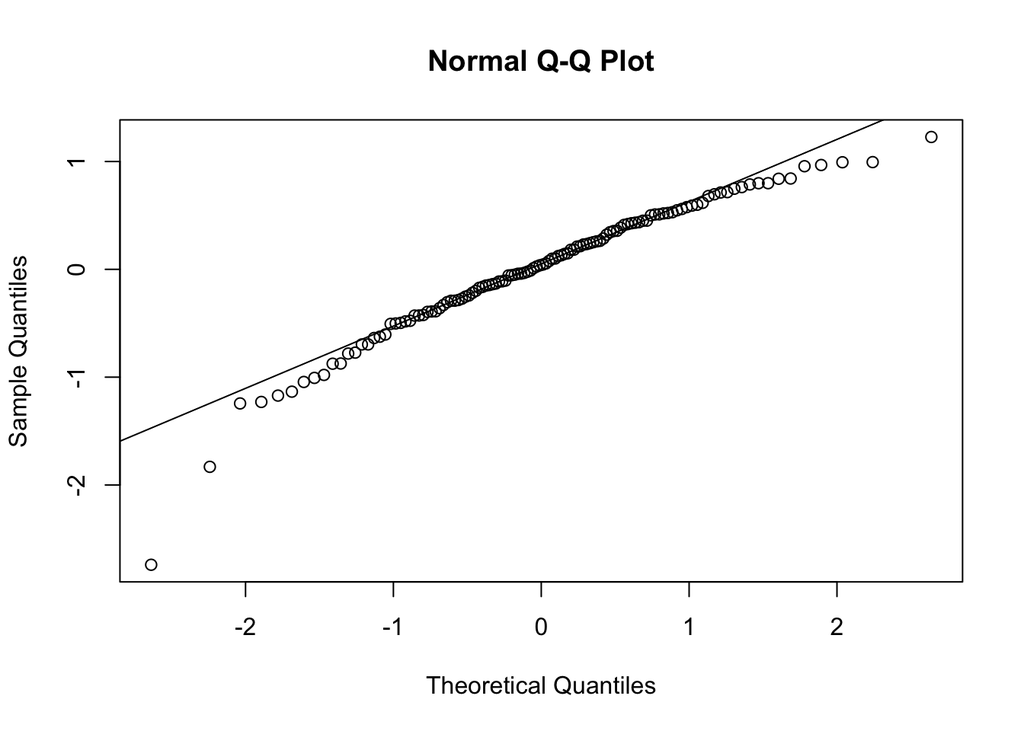

```r
p1.19.qq <- qqnorm(p1.19.lm$residuals)
qqline(p1.19.lm$residuals)
```

```r
names(p1.19.qq)
```

```
## [1] "x" "y"
```

```r
# Comment: p1.19.qq$x are the expected values of the residuals under normality (the x-axis in the qqnorm() plot) to calculate these by hand you would have to use the formulas on page 111 of the textbook.
# Comment: p1.19.qq$y are the actual residuals (the y-axis in the qqnorm() plot)

cor(p1.19.qq$x, p1.19.qq$y) #gives the correlation coefficient of x and y
```

```
## [1] 0.9744497
```

```r
#Using Table B.6 you can look up the ``critical value'' for the correlation for a given sample size. Any correlation that is less than the given critical value rejects the hypothesis that the residuals are normally distributed. Any correlation that is greater than the critical value retains the hypothesis that the residuals are normally  distributed. The critical value for a sample size of 100 and $\alpha=0.05$ is 0.987, which is as good as we can do with Table B.6, even though our sample size for this problem is 120. Hence, we would reject the assumption that the residuals are normally distributed since our correlation coefficient was 0.9744, which is less than the critical value of 0.987.
```

### Part E

> Conduct the Brown-Forsythe test to determine whether or not the error variance varies with the level of $X$. Divide the data into the two groups, $X < 26$, $X\geq 26$, and use $\alpha=0.01$. State the decision rule and conclusion. Does your conclusion support your preliminary findings in part (c)?

Study pages 116-118 to understand how to do the Brown-Forsythe Test. Sadly, to my knowledge there is no nice R function to do this in Linear Regression settings. However, the following R code should make it nice to complete this test “by hand”. You will only understand why I give you this R code if you read pages 116-118.

```r
# Divide the data into two pieces according to the X (ACT) values:
Group1 <- p1.19$X < 26
Group2 <- p1.19$X >= 26

# Find the median of the residuals for each group:
med1 <- median(p1.19.lm$residuals[Group1])
med2 <- median(p1.19.lm$residuals[Group2])

# Find the absolute value of the deviations around each median for each group:
d1 <- abs(p1.19.lm$residuals[Group1] - med1)
d2 <- abs(p1.19.lm$residuals[Group2] - med2)

# Calculate the Brown-Forsythe t test statistic:
s2BF <- ( sum( (d1-mean(d1))^2 ) + sum( (d2-mean(d2))^2 ) )/(120-2)
sBF <- sqrt(s2BF)
tBF <- (mean(d1)-mean(d2))/(sBF*sqrt(1/sum(Group1)+1/sum(Group2)))

# Compute the critical value and compare tBF:
qt(1-0.01/2, 120-2)
```

```
## [1] 2.618137
```

```r
tBF
```

```
## [1] -0.8967448
```

```r
# Compute the two-tailed p-value for a t(n-2) distribution:
2*pt(-abs(tBF), 120-2)
```

```
## [1] 0.371681
```

Using either the Brown-Forsythe t statistic (-0.8967) or the corresponding p-value (0.3717) we would fail to reject the null hypothesis that the error variance is constant. We will continue to assume that the error variance is constant for all levels of $X$.

### Part F

> Information is given [in the textbook] for each student on two variables not included in the model, namely, intelligence test score ($X_2$) and high school class rank percentile ($X_3$). Plot the residuals against $X_2$ and $X_3$ on separate graphs to ascertain whether the model can be improved by including either of these varaibles. What do you conclude?

From pages 112, 113, and 114 we learn how the importance of omitted (i.e., unused) predictor variables can be assessed by considering plots of the residuals on the omitted variables. Figure 3.10 of the textbook especially highlights this idea. Essentially, if the plot of residuals against the omitted (or unused) predictor variable shows a trend, that predictor variable contains important information that should be included in the model. If the plot does not show any trends, then the omitted predictor variable should remain unused. The plots below show that $X_2$ (IQ) should be included in the model because it has information (a trend) that isn’t accounted for by the residuals, while $X_3$ (Rank) should not be included in the model because the residuals have already accounted for any information that variable might contain, no trend in the plot.

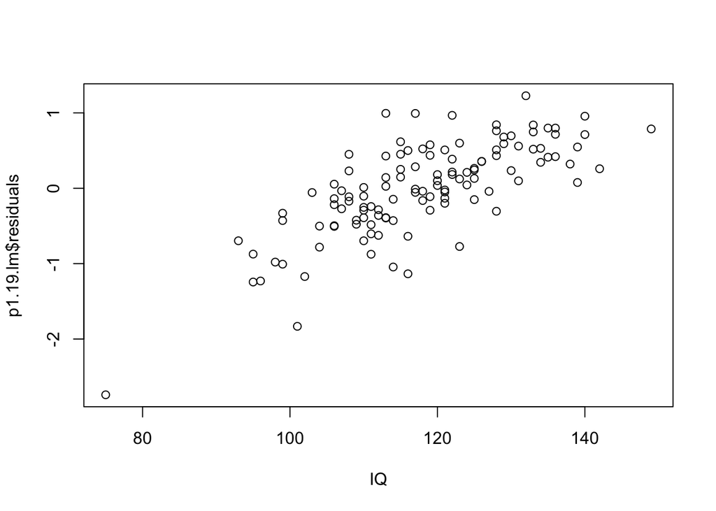

```r
p1.19extra <- read.table("http://www.stat.ufl.edu/~rrandles/sta4210/Rclassnotes/data/textdatasets/KutnerData/Chapter%20%203%20Data%20Sets/CH03PR03.txt")
colnames(p1.19extra) <- c("Y","X","X2","X3")


plot(p1.19.lm$residuals ~ p1.19extra$X2, xlab="IQ")
```

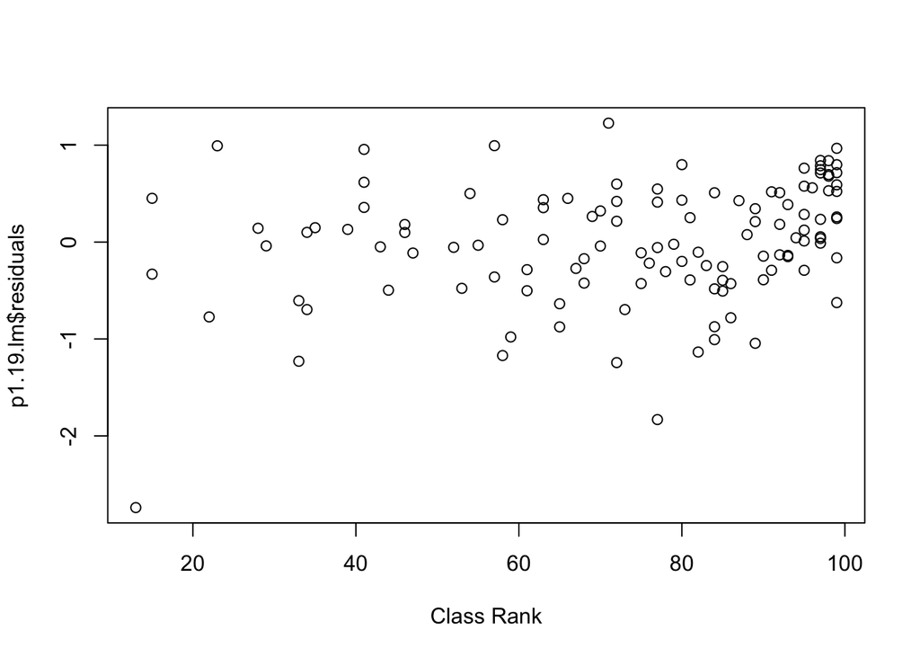

```r
plot(p1.19.lm$residuals ~ p1.19extra$X3, xlab="Class Rank")
```

## Problem 3.7 Solutions

```r
# Load the Data:
p1.27 <- read.table("http://www.stat.ufl.edu/~rrandles/sta4210/Rclassnotes/data/textdatasets/KutnerData/Chapter%20%201%20Data%20Sets/CH01PR27.txt")

# Rewrite the column names to be "Y" and "X" to match the textbook:
colnames(p1.27) <- c("Y","X")

# Look at the top of the dataset
head(p1.27)
```

```
    Y  X
1 106 43
2 106 41
3  97 47
4 113 46
5  96 45
6 119 41
```

##### (a)

```r
stem(p1.27$X, scale=.5)
```

```
##
##   The decimal point is 1 digit(s) to the right of the |
##
##   4 | 111223345677788
##   5 | 12334456777999
##   6 | 000133345556889
##   7 | 0012235666788888
```

Yes, if we control the `scale` command, we can get the stem plot to show one stem for each base of 40’s, 50’s, 60’s, and 70’s so that we can see roughly the same number of observations in each 10-year age group.

##### (b)

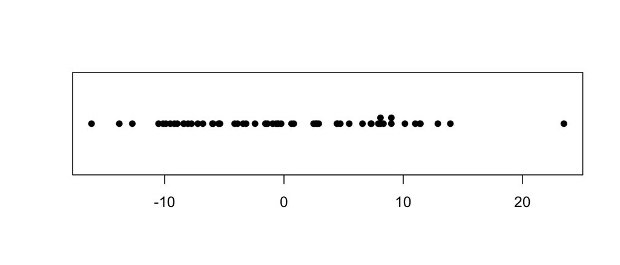

```r
lm.P27 <- lm(Y ~ X, data=p1.27)
stripchart(lm.P27$residuals, method="stack", pch=16)
```

The dotplot of the residuals show that there is good representation between -10 and 10, but that there is an outlying point on the right end and a few low lying points on the left end of the distribution. These values have the potential to be very influential on the fitted regression line.

##### (c)

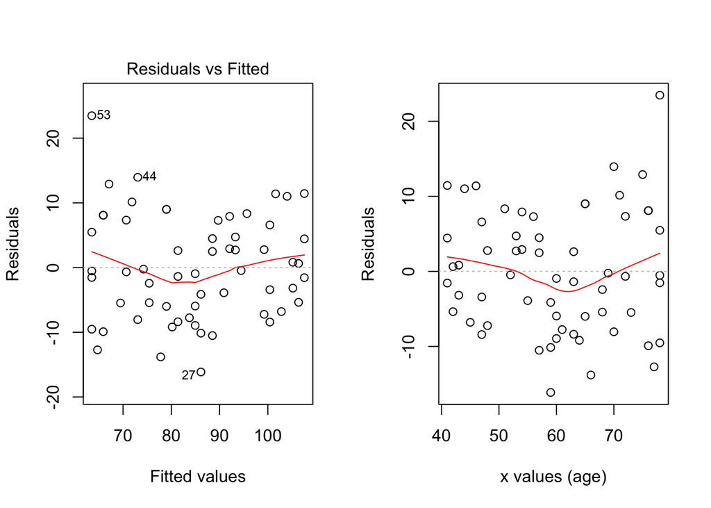

```r
par(mfrow=c(1,2))
# Residuals vs. fitted:
plot(lm.P27, which=1)

# Make the residuals vs. x (by hand):
scatter.smooth(lm.P27$residuals ~ p1.27$X, ylab='Residuals', xlab="x values (age)", lpars=list(col='red'))
abline(h=0, lty=3, col='gray')
```

The two plots show the same information. However, they show it in mirror image because of the negative correlation between `muscle` and `age`. Low fitted values correspond to high x values.

##### (d)

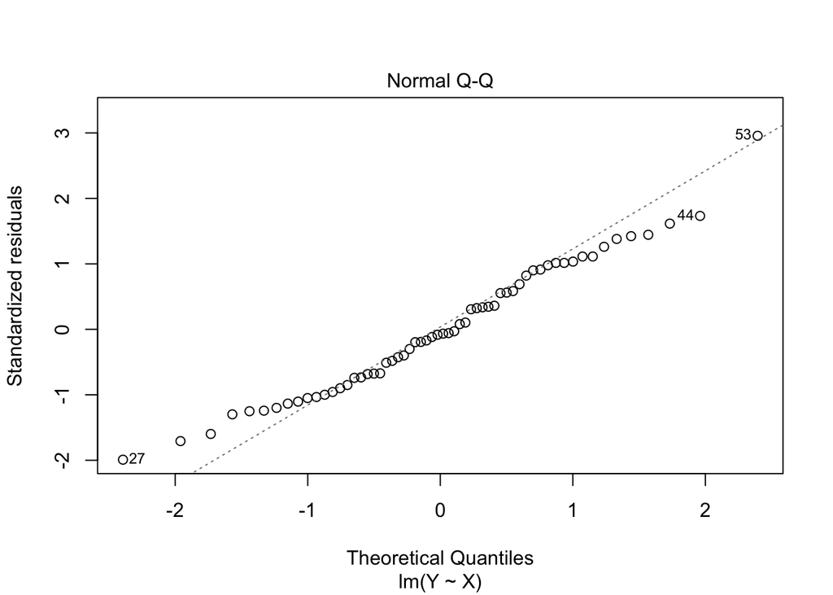

```r
# Make the Q-Q Plot using the default:
plot(lm.P27, which=2)
```

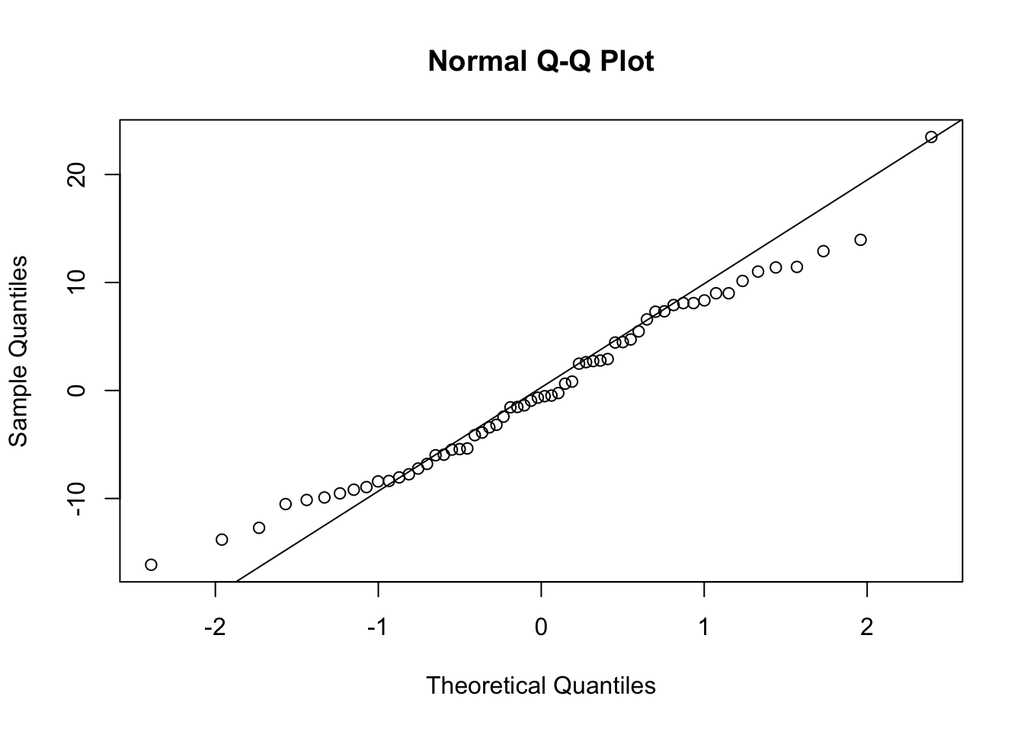

```r
# Make the plot by and and save the x and y values when making the plot:
xy <- qqnorm(lm.P27$residuals)
qqline(lm.P27$residuals)
```

```r
# Compute the correlation of the normality plot:
cor(xy$x, xy$y)
```

```
## [1] 0.9896158
```

The cut-off value for correlation, as given in Table B.6 when the sample size of $n = 60$ and $\alpha=0.10$, is 0.984. Since the obtained correlation of $0.9896158$ is higher than this cut-off, we continue to assume the residuals are normal. (If it was lower than this cut-off, then we would have evidence that the residuals, and thus the true errors, should not be assumed to be normal.)

##### (e)

```r
# First, run the command: install.packages('lmtest')
library(lmtest)
# Then, perform the Breusch-Pagan Test:
bptest(lm.P27, studentize=FALSE)
```

```
##
##  Breusch-Pagan test
##
## data:  lm.P27
## BP = 3.8171, df = 1, p-value = 0.05073
```

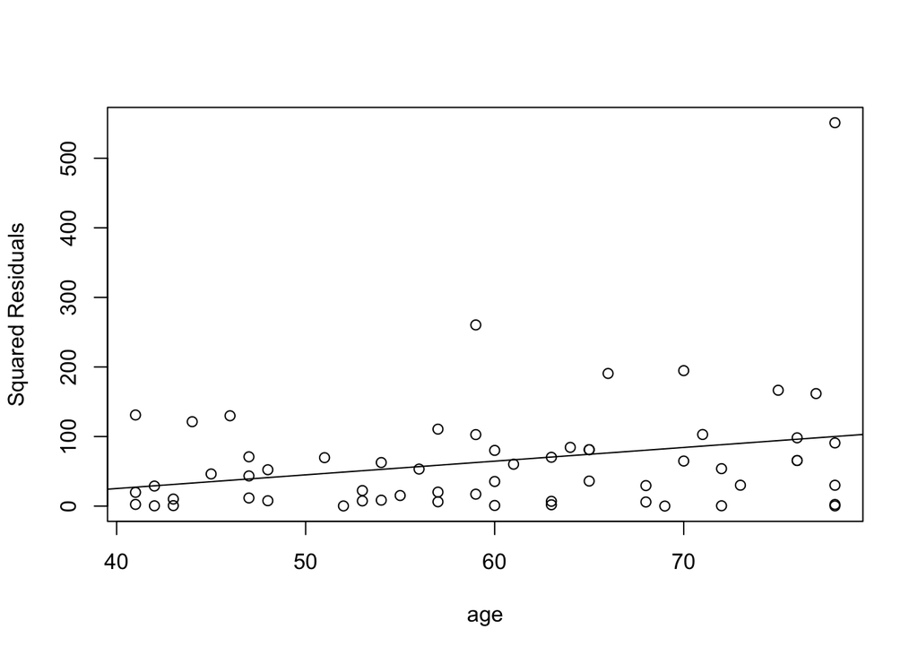

```r
# Or do it by hand (see page 119 of the textbook):
lm.bp.P27 <- lm(lm.P27$residuals^2 ~ p1.27$X)
plot(lm.P27$residuals^2 ~ p1.27$X, ylab="Squared Residuals", xlab="age")
abline(lm.bp.P27)
```

```r
SS.star <- anova(lm.bp.P27)
SS <- anova(lm.P27)
X2.BP <- (SS.star$"Sum Sq"[1]/2) / (SS$"Sum Sq"[2] / nrow(p1.27))^2
X2.BP
```

```
## [1] 3.817125
```

```r
pchisq(X2.BP, 1, lower.tail=FALSE)
```

```
## [1] 0.05073122
```

Doing it the easy way, or by hand, results in the same conclusion, fail to reject the null hypothesis that there is constant variance ($p=0.05073 > 0.01 = \alpha$). The conclusion is supported by the residuals versus fitted values plot shown in part (c) which seemed to show roughly constant variance of the residuals, even though linearity of the model is questionable.